# Data visualization with nbAPI

Andrew Tamalunas

March 23, 2019

Setup

```r
### Get team shot stats for all teams
df <- shots_stats(TeamID = 0, Type = "team")
```

Let’s say that we are interested in finding the teams who shoot the most 3-pointers. Seeing the number of attempts relative to league average is more informative than the raw numbers. Subtracting the league average of a variable from the team’s value for that variable gives us a reference point. So we transform the variable and make a new one for graphically labeling above and below average.

```r
### Transform columns
df <- df %>%
  mutate(FG3A.c = FG3A - mean(FG3A))

### Add seperator variable
df$above.below <- ifelse(df$FG3A.c >= 0, 'Above', 'Below')
```

We should also order the graph.

```r
df <- df[order(df$FG3A.c), ]
df$TEAM_NAME <- factor(df$TEAM_NAME, levels = df$TEAM_NAME)  # keeps order in plot
```

And then make the graph

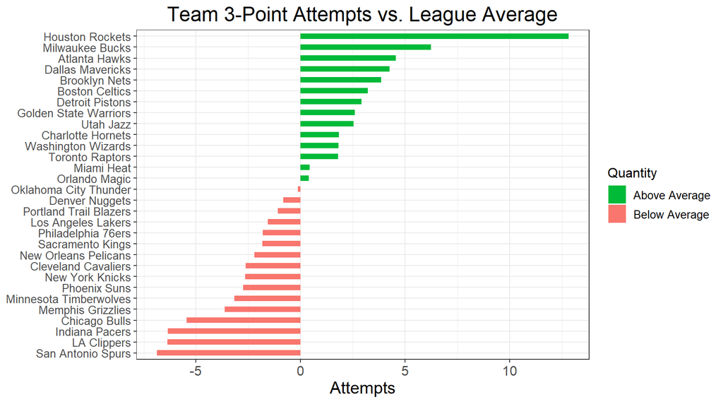

```r
ggplot(df, aes(x = TEAM_NAME, y = FG3A.c, label = FG3A.c)) +
  geom_bar(stat = 'identity', aes(fill = above.below), width=.5)  +
  scale_fill_manual(name = "Quantity",
                    labels = c("Above Average", "Below Average"),
                    values = c("Above" = "#00ba38", "Below" = "#f8766d")) +
  labs(title = "Team 3-Point Attempts vs. League Average",
       y = "Attempts") +
  coord_flip() +
  p1.theme
```

The Rockets attempt more three pointers per game than any other team. Who might be skewing this number to make it so large?

## The Culprit

We start by using the `shots_stats` function again, but retrieving players for a single team this time

```r
### Get team shot stats for Rockets
rockets.id <- df$TEAM_ID[df$TEAM_NAME == 'Houston Rockets']
HOU.df <- shots_stats(TeamID = rockets.id, Type = "player")
### Filter out players with very few games
HOU.df <- HOU.df %>%
  filter(G > 10)
```

We also want a reasonably small number of players to compare

```r
### Get values of top 10 players
HOU.df <- HOU.df %>%
  arrange(desc(FG3A))
top10 <- head(sort(HOU.df$FG3A, decreasing=TRUE), 10)
### Return data frame with all data
HOU.df <- HOU.df[which(HOU.df$FG3A %in% top10), ]
```

Now we can visualize the most frequent 3-point shooters on the Rockets

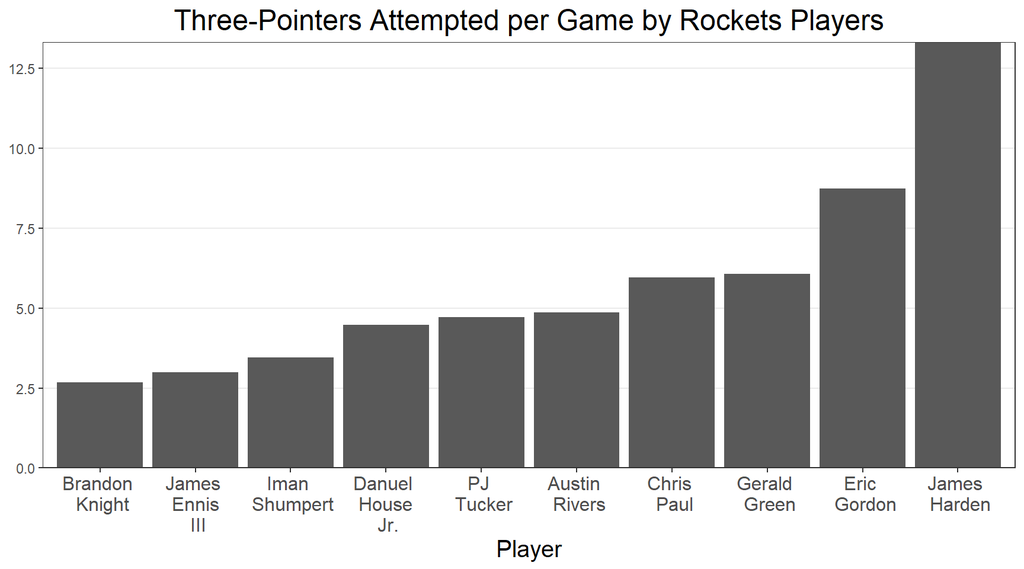

```r
### fix player names for spacing
HOU.df$PLAYER_NAME.g <- gsub(' ', ' \n ', HOU.df$PLAYER_NAME)

ggplot(HOU.df) +
  geom_bar(stat = 'identity', position = position_dodge(width = 0.5),
           aes(x = reorder(PLAYER_NAME.g, FG3A), y = FG3A)) +
  scale_y_continuous(expand = c(0,0)) +
  labs(title = "Three-Pointers Attempted per Game by Rockets Players",
         x = "Player", y = "Attempts") +
  p2.theme
```

It won’t be much of a surprise to NBA fans to see that James Harden’s number of 3-point attempts is way above his teammates… and the league average.